[figure not shown]

Proprietary content. © Great Learning. All Rights Reserved. Unauthorized use or distribution prohibited.

# Face Mask Prediction using U-Net

Task is to predict the mask around the face in a given image.

# Instructions

- Some part of the code is already done for you
- You need to execute all the cells
- You need to add the code where ever you see `"#### Add your code here ####"`
- Marks are mentioned along with the cells

## Dataset

Faces in images marked with bounding boxes. Have around 409 images with around 1000 faces manually tagged via bounding box.

- Data file name: images.npy

### Mount Google drive if you are using google colab

- We recommend using Google Colab as you can face memory issues and longer runtimes while running on local

```python
from google.colab import drive
drive.mount('/content/drive')
```

```python
%tensorflow_version 2.x
import tensorflow
tensorflow.__version__
```

```
'2.3.0'
```

### Load the "images.npy" file (2 marks)

- This file contains images with details of bounding boxes

```python
import numpy as np
data = np.load("/content/drive/My Drive/GL/Dataset/images.npy", allow_pickle=True)
```

### Check one sample from the loaded "images.npy" file (2 marks)

- Hint: print data[10][1]

```python
print(data[41][0])
print(data[41][1])
```

```
[[[114 118 125 255]
  [129 134 141 255]
  [148 153 160 255]
  ...
  [ 92  96  91 255]
  [ 94  96  93 255]
  [ 93  95  91 255]]

 [[110 114 122 255]
  [127 132 140 255]
  [146 150 159 255]
  ...
  [ 95  97  94 255]
  [ 96  97  95 255]
  [ 94  96  92 255]]

 [[109 113 122 255]
  [125 130 140 255]
  [144 149 159 255]
  ...
  [ 97  98  97 255]
  [ 97  99  96 255]
  [ 94  96  92 255]]

 ...

 [[ 16  17  15 255]
  [ 14  15  14 255]
  [ 14  15  14 255]
  ...
  [ 81  80  77 255]
  [ 81  80  78 255]
  [ 81  80  79 255]]

 [[ 16  17  16 255]
  [ 15  16  15 255]
  [ 14  16  14 255]
  ...
  [ 79  78  75 255]
  [ 78  77  75 255]
  [ 78  77  76 255]]

 [[ 14  15  14 255]
  [ 12  14  12 255]
  [ 13  14  13 255]
  ...
  [ 79  78  76 255]
  [ 78  77  76 255]
  [ 78  77  76 255]]]
[{'label': ['Face'], 'notes': '', 'points': [{'x': 0.6996124031007752, 'y': 0.36176470588235293}, {'x': 0.8430232558139535, 'y': 0.5647058823529412}], 'imageWidth': 516, 'imageHeight': 340}]
```

### Set image dimensions (1 mark)

- Initialize image height, image width with value: 224

```python
IMAGE_HEIGHT = 224
IMAGE_WIDTH = 224
```

### Create features and labels

- Here feature is the image
- The label is the mask
- Images will be stored in "X" array
- Masks will be stored in "masks" array

```python
import cv2
from tensorflow.keras.applications.mobilenet import preprocess_input

masks = np.zeros((int(data.shape[0]), IMAGE_HEIGHT, IMAGE_WIDTH))
X = np.zeros((int(data.shape[0]), IMAGE_HEIGHT, IMAGE_WIDTH, 3))
for index in range(data.shape[0]):
    img = data[index][0]
    img = cv2.resize(img, dsize=(IMAGE_HEIGHT, IMAGE_WIDTH), interpolation=cv2.INTER_CUBIC)
    try:
      img = img[:, :, :3]
    except:
      continue
    X[index] = preprocess_input(np.array(img, dtype=np.float32))
    for i in data[index][1]:
        x1 = int(i["points"][0]['x'] * IMAGE_WIDTH)
        x2 = int(i["points"][1]['x'] * IMAGE_WIDTH)
        y1 = int(i["points"][0]['y'] * IMAGE_HEIGHT)
        y2 = int(i["points"][1]['y'] * IMAGE_HEIGHT)
        masks[index][y1:y2, x1:x2] = 1
```

### Split the data into training and testing (2 marks)

- 400 images in training
- 9 images in testing data

Training data

```python
X_train = X[0:400]
y_train = masks[0:400]
print(X_train.shape)
print(y_train.shape)
```

```
(400, 224, 224, 3)
(400, 224, 224)
```

Testing data

```python
X_test = X[400:409]
y_test = masks[400:409]
print(X_test.shape)
print(y_test.shape)
```

```
(9, 224, 224, 3)
(9, 224, 224)
```

### Print a sample training image, image array and its mask (2 marks)

Print the image and image array

```python
import matplotlib.pyplot as plt
def PrintImageData():
  for i in range(0, 400, 46):
    plt.figure(figsize=(10,4))
    plt.subplot(1, 2, 1)
    plt.imshow(X_train[i])
    plt.subplot(1, 2, 2)
    plt.imshow(y_train[i])
    plt.show()
```

Print the mask

```
Clipping input data to the valid range for imshow with RGB data ([0..1] for floats or [0..255] for integers).
```

[figure not shown]

```
Clipping input data to the valid range for imshow with RGB data ([0..1] for floats or [0..255] for integers).
```

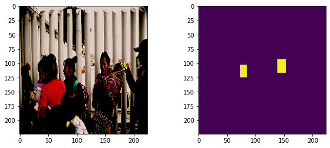

```
Clipping input data to the valid range for imshow with RGB data ([0..1] for floats or [0..255] for integers).
```

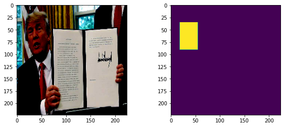

```
Clipping input data to the valid range for imshow with RGB data ([0..1] for floats or [0..255] for integers).
```

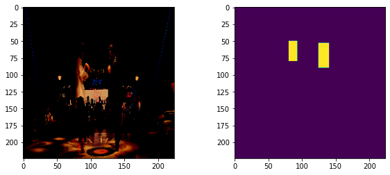

```
Clipping input data to the valid range for imshow with RGB data ([0..1] for floats or [0..255] for integers).
```

[figure not shown]

```
Clipping input data to the valid range for imshow with RGB data ([0..1] for floats or [0..255] for integers).
```

[figure not shown]

```
Clipping input data to the valid range for imshow with RGB data ([0..1] for floats or [0..255] for integers).
```

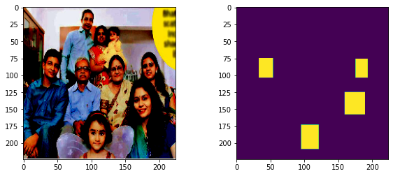

```
Clipping input data to the valid range for imshow with RGB data ([0..1] for floats or [0..255] for integers).
```

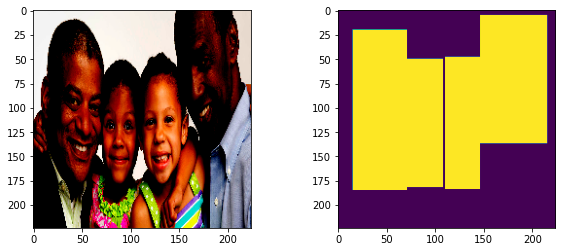

```
Clipping input data to the valid range for imshow with RGB data ([0..1] for floats or [0..255] for integers).
```

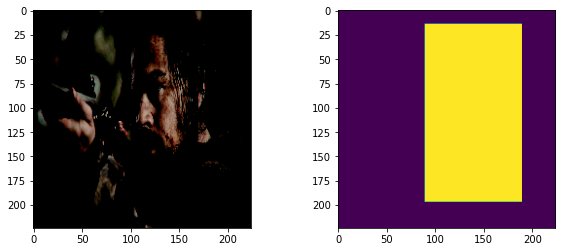

```python
PrintImageData()
```

## Create the model (5 marks)

- Add MobileNet as model with below parameter values
  - input_shape: IMAGE_HEIGHT, IMAGE_WIDTH, 3
  - include_top: False
  - alpha: 1.0
  - weights: "imagenet"
- Add UNET architecture layers
  - This is the trickiest part of the project, you need to research and implement it correctly

```python
from tensorflow.keras.applications.mobilenet import MobileNet
from tensorflow.keras.layers import Reshape, UpSampling2D, Concatenate, Conv2D
from tensorflow.keras.models import Model

def create_model(trainable=True):
    model = MobileNet(input_shape=(IMAGE_HEIGHT, IMAGE_WIDTH, 3), include_top=False, alpha=1.0, weights="imagenet")

    for layer in model.layers:
        layer.trainable = trainable

    block1 = model.get_layer("conv_pw_1_relu").output
    block2 = model.get_layer("conv_pw_3_relu").output
    block3 = model.get_layer("conv_pw_5_relu").output
    block4 = model.get_layer("conv_pw_11_relu").output
    block5 = model.get_layer("conv_pw_13_relu").output

    x = Concatenate()([UpSampling2D()(block5), block4])
    x = Concatenate()([UpSampling2D()(x), block3])
    x = Concatenate()([UpSampling2D()(x), block2])
    x = Concatenate()([UpSampling2D()(x), block1])
    x = UpSampling2D()(x)

    x = Conv2D(1, kernel_size=1, activation="sigmoid")(x)
    x = Reshape((IMAGE_HEIGHT, IMAGE_WIDTH))(x)

    return Model(inputs=model.input, outputs=x)
```

### Call the create_model function (1 mark)

- Give trainable=False as argument, if you want to freeze lower layers for fast training (but low accuracy)

```python
model = create_model(False)
```

### Print model summary (1 mark)

```python
model.summary()
```

```
Model: "functional_1"
__________________________________________________________________________________________________
Layer (type)                    Output Shape         Param #     Connected to
==================================================================================================
input_1 (InputLayer)            [(None, 224, 224, 3) 0
__________________________________________________________________________________________________
conv1_pad (ZeroPadding2D)       (None, 225, 225, 3)  0           input_1[0][0]
__________________________________________________________________________________________________
conv1 (Conv2D)                  (None, 112, 112, 32) 864         conv1_pad[0][0]
__________________________________________________________________________________________________
conv1_bn (BatchNormalization)   (None, 112, 112, 32) 128         conv1[0][0]
__________________________________________________________________________________________________
conv1_relu (ReLU)               (None, 112, 112, 32) 0           conv1_bn[0][0]
__________________________________________________________________________________________________
conv_dw_1 (DepthwiseConv2D)     (None, 112, 112, 32) 288         conv1_relu[0][0]
__________________________________________________________________________________________________
conv_dw_1_bn (BatchNormalizatio (None, 112, 112, 32) 128         conv_dw_1[0][0]
__________________________________________________________________________________________________
conv_dw_1_relu (ReLU)           (None, 112, 112, 32) 0           conv_dw_1_bn[0][0]
__________________________________________________________________________________________________
conv_pw_1 (Conv2D)              (None, 112, 112, 64) 2048        conv_dw_1_relu[0][0]
__________________________________________________________________________________________________
conv_pw_1_bn (BatchNormalizatio (None, 112, 112, 64) 256         conv_pw_1[0][0]
__________________________________________________________________________________________________
conv_pw_1_relu (ReLU)           (None, 112, 112, 64) 0           conv_pw_1_bn[0][0]
__________________________________________________________________________________________________
conv_pad_2 (ZeroPadding2D)      (None, 113, 113, 64) 0           conv_pw_1_relu[0][0]
__________________________________________________________________________________________________
conv_dw_2 (DepthwiseConv2D)     (None, 56, 56, 64)   576         conv_pad_2[0][0]
__________________________________________________________________________________________________
conv_dw_2_bn (BatchNormalizatio (None, 56, 56, 64)   256         conv_dw_2[0][0]
__________________________________________________________________________________________________
conv_dw_2_relu (ReLU)           (None, 56, 56, 64)   0           conv_dw_2_bn[0][0]
__________________________________________________________________________________________________
conv_pw_2 (Conv2D)              (None, 56, 56, 128)  8192        conv_dw_2_relu[0][0]
__________________________________________________________________________________________________
conv_pw_2_bn (BatchNormalizatio (None, 56, 56, 128)  512         conv_pw_2[0][0]
__________________________________________________________________________________________________
conv_pw_2_relu (ReLU)           (None, 56, 56, 128)  0           conv_pw_2_bn[0][0]
__________________________________________________________________________________________________
```

[output cut: 153 more lines]

```
up_sampling2d_3 (UpSampling2D)  (None, 112, 112, 192 0           concatenate_2[0][0]
__________________________________________________________________________________________________
concatenate_3 (Concatenate)     (None, 112, 112, 198 0           up_sampling2d_3[0][0]
                                                                 conv_pw_1_relu[0][0]
__________________________________________________________________________________________________
up_sampling2d_4 (UpSampling2D)  (None, 224, 224, 198 0           concatenate_3[0][0]
__________________________________________________________________________________________________
conv2d (Conv2D)                 (None, 224, 224, 1)  1985        up_sampling2d_4[0][0]
__________________________________________________________________________________________________
reshape (Reshape)               (None, 224, 224)     0           conv2d[0][0]
==================================================================================================
Total params: 3,230,849
Trainable params: 1,985
Non-trainable params: 3,228,864
__________________________________________________________________________________________________
```

### Define dice coefficient function (2 marks)

- Create a function to calculate dice coefficient

```python
def dice_coefficient(y_true, y_pred):
    numerator = 2 * tensorflow.reduce_sum(y_true * y_pred)
    denominator = tensorflow.reduce_sum(y_true + y_pred)

    return numerator / (denominator + tensorflow.keras.backend.epsilon())
```

### Define loss function (2 marks)

```python
def loss(y_true, y_pred):
    return binary_crossentropy(y_true, y_pred) - tensorflow.keras.backend.log(dice_coefficient(y_true, y_pred) + tensorflow.keras.backend.epsilon())
```

### Compile the model (2 marks)

- Complie the model using below parameters
  - loss: use the loss function defined above
  - optimizers: use Adam optimizer
  - metrics: use dice_coefficient function defined above

```python
from tensorflow.keras.optimizers import Adam
from tensorflow.keras.losses import binary_crossentropy

optimizer = Adam(lr=1e-3, beta_1=0.9, beta_2=0.999, epsilon=None, decay=0.0, amsgrad=False)
model.compile(loss=loss, optimizer=optimizer, metrics=[dice_coefficient])
```

### Define callbacks (2 marks)

- Use ModelCheckpoint
- Use EarlyStopping
- Use ReduceLROnPlateau

```python
from tensorflow.keras.callbacks import ModelCheckpoint, EarlyStopping, ReduceLROnPlateau

checkpoint = ModelCheckpoint("model-{epoch:02d}-{val_loss:.2f}.h5", monitor="val_loss", verbose=1, save_best_only=True, save_weights_only=True)
stop = EarlyStopping(monitor="val_loss", patience=5)
reduce_lr = ReduceLROnPlateau(monitor="val_loss", factor=0.2, patience=5, min_lr=1e-6, verbose=1)
```

### Fit the model (2 marks)

- Fit the model using below parameters
  - epochs: you can decide
  - batch_size: 1
  - callbacks: use the callbacks defined above

```python
model.fit(X_train, y_train, validation_data = (X_test, y_test), epochs=50, batch_size=1, verbose=1, callbacks = [checkpoint, stop, reduce_lr])
```

```
Epoch 00001: val_loss improved from inf to 0.90246, saving model to model-01-0.90.h5
Epoch 00002: val_loss improved from 0.90246 to 0.80329, saving model to model-02-0.80.h5
Epoch 00003: val_loss improved from 0.80329 to 0.75158, saving model to model-03-0.75.h5
Epoch 00004: val_loss did not improve from 0.75158
Epoch 00005: val_loss did not improve from 0.75158
Epoch 00006: val_loss did not improve from 0.75158
Epoch 00007: val_loss did not improve from 0.75158
Epoch 00008: val_loss did not improve from 0.75158

Epoch 00008: ReduceLROnPlateau reducing learning rate to 0.00020000000949949026.
```

```
<tensorflow.python.keras.callbacks.History at 0x7fdcefa12e10>
```

### Get the predicted mask for a test image (2 marks)

Show the test image

```
Clipping input data to the valid range for imshow with RGB data ([0..1] for floats or [0..255] for integers).
```

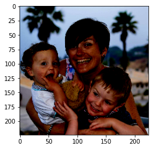

```python
index = 0
plt.imshow(X_test[index])
```

Show original mask for test image

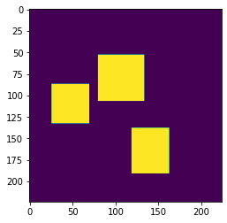

```python
plt.imshow(y_test[index])
```

Predict the mask on the test image

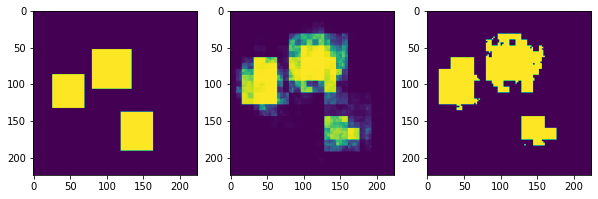

```python
img = np.expand_dims(np.array(X_test[index], dtype=np.float32), axis=0)
pred_mask = model.predict(x = img)
img_r = cv2.resize(1.0*(pred_mask[0] > 0.5), (IMAGE_WIDTH,IMAGE_HEIGHT))
img = cv2.resize(pred_mask[0], (IMAGE_WIDTH,IMAGE_HEIGHT))

plt.figure(figsize=(10,4))
plt.subplot(1,3,1)
plt.imshow(y_test[index])
plt.subplot(1,3,2)
plt.imshow(img)
plt.subplot(1,3,3)
plt.imshow(img_r)
plt.show()
```

### Impose the mask on the test image (2 marks)

- In imshow use the alpha parameter and set it to greater than 0.5

```
Clipping input data to the valid range for imshow with RGB data ([0..1] for floats or [0..255] for integers).
Clipping input data to the valid range for imshow with RGB data ([0..1] for floats or [0..255] for integers).
Clipping input data to the valid range for imshow with RGB data ([0..1] for floats or [0..255] for integers).
```

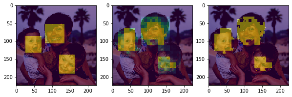

```python
ori_img = X_test[index]
mask_img = img
mask_img_r = img_r

plt.figure(figsize=(10,4))
plt.subplot(1,3,1)
plt.imshow(ori_img, interpolation='none')
plt.imshow(y_test[index], alpha=0.5, interpolation='none')
plt.subplot(1,3,2)
plt.imshow(ori_img, interpolation='none')
plt.imshow(mask_img, alpha=0.5, interpolation='none')
plt.subplot(1,3,3)
plt.imshow(ori_img, interpolation='none')
plt.imshow(mask_img_r, alpha=0.5, interpolation='none')
plt.show()
```